# Enunciado

El presente ejercicio es similar al caso práctico de repaso de optimización de campañas de marketing online ya realizado y lo que se pretende con este es asentar los conceptos relativos al algoritmo del bandido multibrazo, como son las ratios de explotación y exploración para la optimización de una campaña de marketing online.

Al igual que en el caso práctico de repaso, se tiene que hacer una campaña de marketing online para promocionar un determinado producto con la que se mostrará en una página web un banner con una imagen del producto que promocionar. Se han realizado cinco imágenes distintas del producto para poner en el banner con el objetivo de captar la atención del usuario para que pulse en el banner y acceda a la web con los detalles del producto que promocionar, pero, a diferencia del caso práctico de repaso, los resultados obtenidos serán diferentes, siendo otra imagen la que mayor valor de Q tenga calculado a partir de la siguiente fórmula:

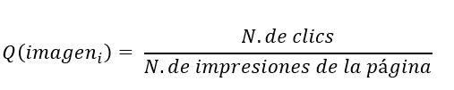

Sin saber a priori cuál es la imagen que captará mayor atención, se debe aprender con base en los clics que se realizan sobre el banner qué imagen será las más llamativa y conseguirá más visitas aplicando el método del bandido multibrazo.

El objetivo es encontrar la imagen que capte mayor atención de los usuarios, es decir que mayor número de clics obtenga:

Dado el método ya implementado en el notebook “multi_armed_bandit(num_games=1000, epsilon=0.1, verbose=False)”, se pide, modificando el valor de épsilon, responder a la siguientes preguntas para asentar los conceptos relativos al aprendizaje por refuerzo y, en particular, al algoritmo del bandido multibrazo:

1. ¿Cuál es el valor de épsilon que maximiza la imagen con mayor número de clics?
2. ¿Cuál es la imagen que más clics obtiene y cuántos?
3. Poniendo una ratio de explotación del 100%, ¿Qué resultado se obtiene?

Todas estas preguntas deben de ser contestadas en el propio notebook.

Para la realización de este ejercicio, tal como nos pide el enunciado, primeramente traeremos a este notebook la función implementada en el ejercicio de repaso del módulo.

```python
# Librerías
import random
import numpy as np
import matplotlib.pyplot as plt
%matplotlib inline
```

```python
# Funciones
def multi_armed_bandit(num_games=1000, epsilon=0.1, verbose=False, bandits = [0.1, 0.05, 0.03, 0.7, 0.02]):
    total_reward = 0
    acum_reward_bandit = np.zeros(len(bandits))  # numerador
    num_selected_bandit = np.zeros(len(bandits)) # denominador
    q_bandits = np.zeros(len(bandits))            # Q(a)

    if verbose:
        print("Initial Bandits Distribution\n  {}".format(bandits))

    for game in range(0,num_games):

        old_q_bandits = q_bandits.copy()

        if np.random.random() < epsilon:
            bandit = np.random.randint(len(bandits)) # Exploro
        else:
            bandit = np.random.choice(np.flatnonzero(q_bandits == q_bandits.max())) # Exploto

        # Obtengo el reward
        reward = 1 if (np.random.random() < bandits[bandit]) else 0

        # Actualizo reward total
        total_reward += reward

        # Actualizo valor (Q) de la imagen
        acum_reward_bandit[bandit] += reward
        num_selected_bandit[bandit] += 1
        q_bandits[bandit] = acum_reward_bandit[bandit] / num_selected_bandit[bandit]

        if verbose:
            print("\nGAME {game}\n  Old Q_Bandits = {old_q_bandits}\n  Selected Bandit = {bandit} \
                  \n  Reward = {reward}\n  Q_Bandits = {q_bandits}"
                  .format(game=game+1, old_q_bandits=old_q_bandits, bandit=bandit,
                          reward=reward, q_bandits=q_bandits))

    return bandits, total_reward, q_bandits, num_selected_bandit


# Generador de lista de números aleatorios; se "trampea" para que no sea superior a 0.75
def generar_lista(_n=5):
    numbers = np.random.exponential(scale=0.1, size=_n)
    numbers = np.round(numbers, 2)

    return list(numbers)


# Imprimir por pantalla los valores
def print_values(_result):
    print(f"Bandits original: {_result[0]}\nNúmero de clicks: {_result[1]} \
            \nTasa de recompensa de cada imagen: {np.round(_result[2], 4)} \nNúmero de veces impresa: {_result[3]}")
```

Sobre la función se va a realizar una pequeña modificación que nos permita introducir como parámetro cualquier combinación numérica como "bandits", de forma que, desde fuera de la función, podamos decidir qué imágenes serán las más aceptadas y cuáles las que menos. Como esta información, *a priori*, es desconocida para nosotros, vamos a crear una función que nos devuelva una lista de números que cumpla exactamente con las mismas condiciones que la lista *bandits* del ejercicio de repaso, y con ella procederemos a realizar los cálculos y estudiar los resultados.

```python
# Generamos un conjunto de "bandits" aleatorio que cumpla con todas las condiciones del parámetro del ejercicio de repaso
bandits = generar_lista()
bandits
```

```
[0.18, 0.28, 0.09, 0.27, 0.75]
```

Aunque debería ser información desconocida, vamos a visualizar el conjunto para poder comprobar *a posteriori* si los resultados coinciden con los números aleatorios generados.

### 1. ¿Cuál es el valor de épsilon que maximiza la imagen con mayor número de clics?

```python
# Para épsilon = 0.1
a=multi_armed_bandit(bandits=bandits)
print_values(a)
```

```
Bandits original: [0.18, 0.28, 0.09, 0.27, 0.75]
Número de clicks: 709
Tasa de recompensa de cada imagen: [0.1765 0.2857 0.0769 0.2632 0.7428]
Número de veces impresa: [ 17.  14.  13.  19. 937.]
```

```python
# Para épsilon = 0.05
b=multi_armed_bandit(epsilon=0.05, bandits=bandits)
print_values(b)
```

```
Bandits original: [0.18, 0.28, 0.09, 0.27, 0.75]
Número de clicks: 680
Tasa de recompensa de cada imagen: [0.1    0.2778 0.1538 0.0714 0.7435]
Número de veces impresa: [ 20.  72.  13.  14. 881.]
```

```python
# Para épsilon = 0.15
c=multi_armed_bandit(epsilon=0.15, bandits=bandits)
print_values(c)
```

```
Bandits original: [0.18, 0.28, 0.09, 0.27, 0.75]
Número de clicks: 641
Tasa de recompensa de cada imagen: [0.1935 0.2692 0.1935 0.2239 0.7383]
Número de veces impresa: [ 62.  26.  31.  67. 814.]
```

```python
# Para épsilon = 0.2
d=multi_armed_bandit(epsilon=0.2, bandits=bandits)
print_values(d)
```

```
Bandits original: [0.18, 0.28, 0.09, 0.27, 0.75]
Número de clicks: 632
Tasa de recompensa de cada imagen: [0.2326 0.2976 0.02   0.2692 0.739 ]
Número de veces impresa: [ 43.  84.  50.  26. 797.]
```

```python
# Para épsilon = 0.5
e=multi_armed_bandit(epsilon=0.5, bandits=bandits)
print_values(e)
```

```
Bandits original: [0.18, 0.28, 0.09, 0.27, 0.75]
Número de clicks: 537
Tasa de recompensa de cada imagen: [0.0928 0.266  0.0889 0.271  0.7614]
Número de veces impresa: [ 97.  94.  90. 107. 612.]
```

```python
# Mayor número de clicks obtenidos en las 5 pruebas
pruebas = [a,b,c,d,e]
_max=0
for prueba in pruebas:
    if(prueba[1] > _max):
        _max = prueba[1]

print(_max)
```

```
709
```

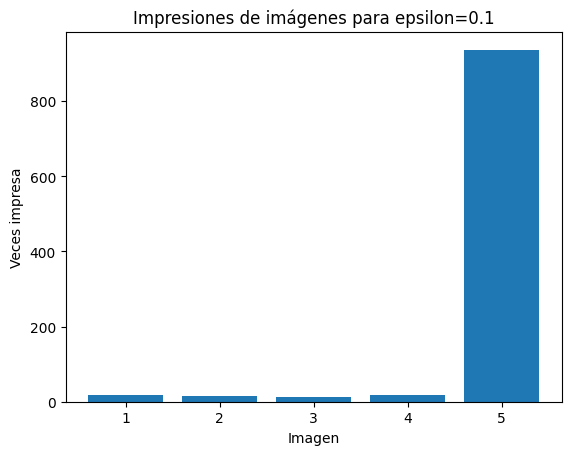

```python
plt.title('Impresiones de imágenes para epsilon=0.1')
plt.bar(range(1,len(bandits)+1), a[3])
plt.xlabel('Imagen')
plt.ylabel('Veces impresa')
plt.show()
```

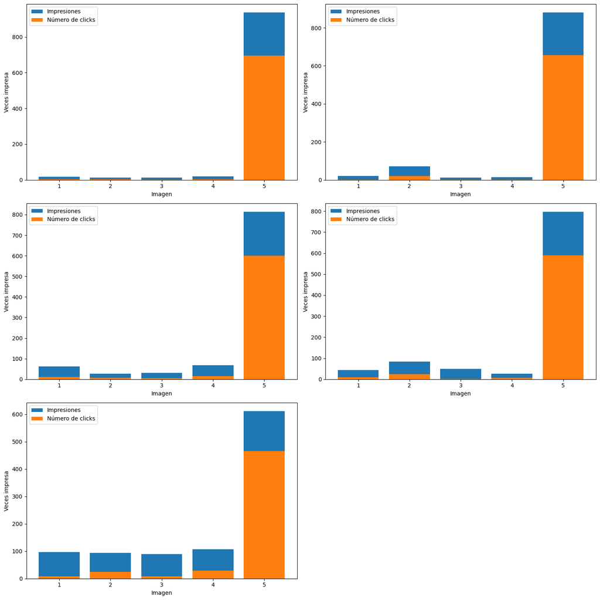

```python
# Comparativa de las distribuciones de las distintas pruebas para épsilon igual a 0.1, 0.05, 0.15, 0.2 y 0.5
fig, axs = plt.subplots(3, 2, figsize=(15, 15))

axs = axs.flatten()

for i, prueba in enumerate(pruebas):
    impresion = prueba[3]
    clicks = prueba[2]*prueba[3]
    axs[i].bar(np.arange(len(pruebas))+1, impresion, label='Impresiones')
    axs[i].bar(np.arange(len(pruebas))+1, clicks, label='Número de clicks')
    axs[i].set_xlabel('Imagen')
    axs[i].set_ylabel('Veces impresa')
    axs[i].legend()

for j in range(len(pruebas), len(axs)):
    fig.delaxes(axs[j])


plt.tight_layout()
plt.show()
```

El método epsilon-greedy es una estrategia muy común en el algoritmo del bandido multibrazo, donde épsilon define la probabilidad con la que el algoritmo explora (elige una imagen al azar, independientemente de cuál sea en ese momento la que más clicks consigue), siendo 1 - épsilon la probabilidad con la que el algoritmo explota (es decir, elige la imagen más valorada en ese momento para mostrar).

Si se prueban diferentes valores de épsilon para el mismo conjunto de imágenes, vemos que en el rango de épsilon = [0.05, 0.2] se obtienen los mayores números de clicks para la última foto (que es, a la postre, la que tiene mayor tasa de éxito en nuestra lista de ratios generada aleatoriamente), todos por encima de los 600 clicks, siendo el máximo número de clicks el alcanzado por la prueba realizada para épsilon igual a 0.1. Cuanto menos se 'imprime' la imagen 5, menor es el número total de clicks que se consiguen.

Esto se puede ver en la última prueba, cuando se pasó a la función un valor para épsilon muy elevado (0.5, es decir, para cada impresión, el algoritmo tiene la misma probabilidad de explorar o actuar de manera aleatoria, que de explotar o mostrar la 'mejor' imagen hasta ese momento). En esta prueba, el número de veces que se imprimió la última imagen fue de 612 veces, bastante menos que en la segunda prueba con menor número de impresiones (797) y se obtuvieron casi 100 clicks menos que en la segunda prueba con menor número de clicks (en torno a un 15-16% menos clicks).

En conclusión, épsilon debe estar en un rango de valores entre 0.05 y 0.2 (siendo 0.1 el que maximizó la recompensa en las pruebas).

### 2. ¿Cuál es la imagen que más clics obtiene y cuántos?

En las pruebas realizadas para distintos valores de épsilon, teniendo en cuenta el rango de valores [0.05, 0.2] elegido como óptimo para maximizar el número de clicks, la imagen que obtiene mayor número de clicks es la última imagen (o imagen 5).

Dado que el número de veces que ha sido impresa esta imagen oscila entre 797 y 937 para el rango descrito, y su tasa de recompensa está en torno a 0.73-0.74, el número de clicks de la quinta imagen, seleccionada como la "mejor" en esta campaña de marketing, estará entre 600 y 700 aproximadamente.

### 3. Poniendo una ratio de explotación del 100%, ¿Qué resultado se obtiene?

Un ratio de explotación del 100% implica un épsilon = 0, ya que no se exploraría nada y todas las veces se explotaría. En la práctica, ésto significa que el algoritmo siempre elegirá la opción con mayor valor de Q, en este caso, la imagen con mayor ratio de clicks/impresiones, y nunca mostrará una imagen al azar (exploración). En el momento inicial, como ninguna imagen ha sido mostrada, todas tienen un Q igual a 0, por tanto, todas son "igual de buenas", no hay ninguna mejor ni peor, por lo que el algoritmo seleccionará una al azar. En el momento en que una de las imágenes obtenga su primer click, su Q pasará a ser mayor que 0, por lo que pasará a ser la mejor imagen y, desde entonces y hasta haber mostrado las 1000 impresiones, el algoritmo sólo seleccionará a ésta, puesto que nunca probará otras opciones y, por tanto, no dará al resto de imágenes la oportunidad de mejorar el valor de su Q.

```python
f=multi_armed_bandit(epsilon=0, bandits=bandits)
print_values(f)
```

```
Bandits original: [0.18, 0.28, 0.09, 0.27, 0.75]
Número de clicks: 184
Tasa de recompensa de cada imagen: [0.1844 0.     0.     0.     0.    ]
Número de veces impresa: [998.   1.   0.   1.   0.]
```

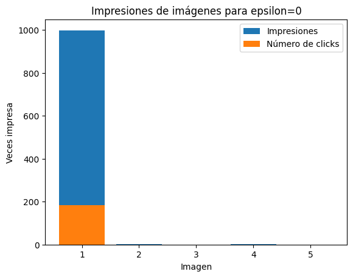

```python
plt.title('Impresiones de imágenes para epsilon=0')
plt.bar(range(1,len(bandits)+1), f[3], label='Impresiones')
plt.bar(range(1,len(bandits)+1), f[2]*f[3], label='Número de clicks')
plt.xlabel('Imagen')
plt.ylabel('Veces impresa')
plt.legend()
plt.show()
```

En la prueba con un epsilon=0 se puede ver lo que se esperaba: el algoritmo, en un inicio, ha seleccionado la imagen 2 o 4, la ha mostrado y el usuario no ha hecho click; al segundo usuario le ha mostrado la otra de esas dos imágenes, y tampoco ha hecho click. Es por ello que ambas imágenes tienen un número de veces impresa de 1 y una tasa de recompensa de 0. En tercer lugar, el algoritmo ha mostrado al siguiente usuario la imagen 1, y éste ha hecho click en ella, mejorando su tasa de recompensa por encima de 0. Es a partir de este momento en que ya no todas las imágenes son igualmente buenas, ya hay una mejor, por lo que el algoritmo, al que se la ha dicho que debe explotar el 100% de las veces, sólo mostrará la "mejor" imagen y nunca probará. De ahí que el resto de veces hasta 1000 haya mostrado la imagen 1, acumulando un total de 998 impresiones, y no haya dado la oportunidad a las imágenes 3 y 5, ni haya vuelto a mostrar las imágenes 2 y 4.

Como conclusión, ante esta situación, se puede ver que el número de clicks obtenidos es muy inferior a los obtenidos en las pruebas con épsilon en el rango [0.05, 0.2], pasando de estar por encima de 600 a apenas 184 clicks. Si el primer click hubiera sido para la imagen 5 (que hemos concluido que es la mejor), quizá los resultados hubieran sido muy diferentes puesto que 998 impresiones de la "mejor" imagen hubieran resultado en muchos clicks, pero, aún así, no es buena opción cerrar del todo la puerta a la exploración, pues siempre se pueden encontrar mejores alternativas (incluso cuando se cree que ya se ha encontrado la mejor - recordemos que no conocemos *a priori* que la quinta imagen es la que tiene mejor ratio de clicks en el *bandits* original). Por lo tanto, siempre es bueno dejar un porcentaje para explorar mientras se explota la que en cada momento sea la mejor opción.